# Assignment5

Aijing

10/5/2020

```r
library(tidyverse)
library(jtools)
library(interactions)
library(knitr)
library(ggplot2)
```

# Original Model

Dependent Variable: avg travel time to workplace: avg_travel_time

Independent Variables:

1. median income: med_income
2. percentage of labour force using public transit to workplace(hereafter, public transit percentage), pct_publictrans
3. majority race: maj_race
4. majority foreign or native born: maj_foreign

```r
tract_data <- read_csv("tracts2018_ma.csv") %>%
  mutate(maj_race = case_when(
    maj_race=="hs_latino" ~ "Hispanic/Latino",
    maj_race=="black" ~ "Black not Hispanic/Latino",
    maj_race=="white" ~ "-White not Hispanic/Latino",
    maj_race=="asian" ~ "Asian not Hispanic/Latino",
    maj_race=="no_majority" ~ "No Majority")) %>%
  mutate(pct_publictrans = pct_publictrans*100)
model1 <- lm( avg_travel_time~ med_incomeE + pct_publictrans + maj_race + maj_foreign,
            data = tract_data)
summary(model1)
```

```
##
## Call:
## lm(formula = avg_travel_time ~ med_incomeE + pct_publictrans +
##     maj_race + maj_foreign, data = tract_data)
##
## Residuals:
##      Min       1Q   Median       3Q      Max
## -17.6712  -3.0334   0.3615   3.2545  13.8052
##
## Coefficients:
##                                     Estimate Std. Error t value Pr(>|t|)
## (Intercept)                        1.841e+01  4.072e-01  45.207  < 2e-16 ***
## med_incomeE                        1.541e-04  9.616e-06  16.029  < 2e-16 ***
## pct_publictrans                    1.057e-01  1.195e-02   8.852  < 2e-16 ***
## maj_raceAsian not Hispanic/Latino -1.203e+00  1.954e+00  -0.615  0.53835
## maj_raceBlack not Hispanic/Latino  4.282e+00  8.793e-01   4.870 1.24e-06 ***
## maj_raceHispanic/Latino           -1.932e+00  6.541e-01  -2.954  0.00319 **
## maj_raceNo Majority                8.225e-01  4.438e-01   1.853  0.06403 .
## maj_foreignTRUE                    2.941e+00  1.025e+00   2.869  0.00418 **
## ---
## Signif. codes:  0 '***' 0.001 '**' 0.01 '*' 0.05 '.' 0.1 ' ' 1
##
## Residual standard error: 4.697 on 1451 degrees of freedom
## Multiple R-squared:  0.2708, Adjusted R-squared:  0.2673
## F-statistic: 76.98 on 7 and 1451 DF,  p-value: < 2.2e-16
```

# Log Transformation

The difference between earning $5,000 per year and $10,000 is probably more substantial than the difference between earning $50,000 per year and $55,000 per year. In the former case, income has increased by 100%, and in the latter, income has increased by 10%. In the case of income and average travel time, I think percentage increases are more relevant than absolute increases, so below i will log-tranform my median income variable.

```r
model2 <- lm(avg_travel_time~ log(med_incomeE) + pct_publictrans + maj_race + maj_foreign,
            data = tract_data)

summary(model2)
```

```
##
## Call:
## lm(formula = avg_travel_time ~ log(med_incomeE) + pct_publictrans +
##     maj_race + maj_foreign, data = tract_data)
##
## Residuals:
##      Min       1Q   Median       3Q      Max
## -17.8922  -2.9189   0.3427   3.0691  13.2089
##
## Coefficients:
##                                    Estimate Std. Error t value Pr(>|t|)
## (Intercept)                       -41.29837    3.09602 -13.339  < 2e-16 ***
## log(med_incomeE)                    6.25621    0.29448  21.245  < 2e-16 ***
## pct_publictrans                     0.10836    0.01114   9.730  < 2e-16 ***
## maj_raceAsian not Hispanic/Latino  -0.38666    1.85244  -0.209  0.83469
## maj_raceBlack not Hispanic/Latino   4.68379    0.82584   5.672 1.71e-08 ***
## maj_raceHispanic/Latino            -0.88599    0.62244  -1.423  0.15483
## maj_raceNo Majority                 1.31172    0.41657   3.149  0.00167 **
## maj_foreignTRUE                     2.58029    0.97060   2.658  0.00794 **
## ---
## Signif. codes:  0 '***' 0.001 '**' 0.01 '*' 0.05 '.' 0.1 ' ' 1
##
## Residual standard error: 4.451 on 1451 degrees of freedom
## Multiple R-squared:  0.3453, Adjusted R-squared:  0.3422
## F-statistic: 109.3 on 7 and 1451 DF,  p-value: < 2.2e-16
```

# Converting a continuous variable to a categorical variable

I suspect the influence of median income on public transit percentage is not in a linear but step-wise fashion, i.e. once people’s income have reached certain thresholds the influence on average travel time will be more or less homogeneous within that band. So I decide to test out this by divide median income variable by 4 bands: low-income 0~25,000, lower_medium-income:25,000~50,000, higher_medium-income:50,000~75,000 and high-income: 75,000 above.

```r
tract_data2 <- tract_data %>%
  mutate(income_group = case_when(med_incomeE < 25000 ~ "-Low_income",
                               25000 <= med_incomeE &  med_incomeE< 50000 ~ "Lower_Medium_income",
                               50000 <= med_incomeE &  med_incomeE< 75000 ~ "Higher_Medium_income",
                               med_incomeE >= 75000 ~ "High_income"))

model3 <- lm(avg_travel_time~ income_group +  pct_publictrans+ maj_race + maj_foreign,
            data = tract_data2)

summary(model3)
```

```
##
## Call:
## lm(formula = avg_travel_time ~ income_group + pct_publictrans +
##     maj_race + maj_foreign, data = tract_data2)
##
## Residuals:
##      Min       1Q   Median       3Q      Max
## -17.9109  -3.1391   0.4067   3.2886  15.1537
##
## Coefficients:
##                                   Estimate Std. Error t value Pr(>|t|)
## (Intercept)                       19.00175    0.38064  49.921  < 2e-16 ***
## income_groupHigh_income            6.11086    1.00114   6.104 1.33e-09 ***
## income_groupHigher_Medium_income   7.63102    0.48956  15.587  < 2e-16 ***
## income_groupLower_Medium_income    5.72515    0.38859  14.733  < 2e-16 ***
## pct_publictrans                    0.11982    0.01195  10.027  < 2e-16 ***
## maj_raceAsian not Hispanic/Latino -0.69682    1.95516  -0.356  0.72159
## maj_raceBlack not Hispanic/Latino  5.11090    0.89147   5.733 1.20e-08 ***
## maj_raceHispanic/Latino           -0.74032    0.67907  -1.090  0.27581
## maj_raceNo Majority                1.00193    0.44653   2.244  0.02499 *
## maj_foreignTRUE                    2.84877    1.02289   2.785  0.00542 **
## ---
## Signif. codes:  0 '***' 0.001 '**' 0.01 '*' 0.05 '.' 0.1 ' ' 1
##
## Residual standard error: 4.684 on 1449 degrees of freedom
## Multiple R-squared:  0.2758, Adjusted R-squared:  0.2713
## F-statistic: 61.33 on 9 and 1449 DF,  p-value: < 2.2e-16
```

The overall fit slightly improves as r-square increase by 0.004 compared to my original model. Interestingly, the new model shows a move from low-income to any of the other 3 groups all have a positive statically significant correlation with average travel time at a 95% confidence level. While a move from low-income to higher medium-income has the most prominent effect: it will increase travel time by 7.63 minutes.

# Adding an interaction term

```r
model4 <- lm(avg_travel_time ~ log(med_incomeE) + pct_publictrans + maj_race + maj_foreign + log(med_incomeE):maj_race,
            data = tract_data)

summary(model4)
```

```
##
## Call:
## lm(formula = avg_travel_time ~ log(med_incomeE) + pct_publictrans +
##     maj_race + maj_foreign + log(med_incomeE):maj_race, data = tract_data)
##
## Residuals:
##      Min       1Q   Median       3Q      Max
## -17.8473  -2.9188   0.3255   3.0401  12.6386
##
## Coefficients:
##                                                    Estimate Std. Error t value
## (Intercept)                                        -38.9416     3.3046 -11.784
## log(med_incomeE)                                     6.0350     0.3141  19.214
## pct_publictrans                                      0.1057     0.0112   9.442
## maj_raceAsian not Hispanic/Latino                  -20.7633    32.4998  -0.639
## maj_raceBlack not Hispanic/Latino                   13.8402    39.1984   0.353
## maj_raceHispanic/Latino                            -45.7406    18.5361  -2.468
## maj_raceNo Majority                                -11.0455    10.1287  -1.091
## maj_foreignTRUE                                      2.3160     0.9870   2.347
## log(med_incomeE):maj_raceAsian not Hispanic/Latino   1.9915     3.1606   0.630
## log(med_incomeE):maj_raceBlack not Hispanic/Latino  -0.9157     3.8959  -0.235
## log(med_incomeE):maj_raceHispanic/Latino             4.5286     1.8740   2.416
## log(med_incomeE):maj_raceNo Majority                 1.2169     0.9975   1.220
##                                                    Pr(>|t|)
## (Intercept)                                          <2e-16 ***
## log(med_incomeE)                                     <2e-16 ***
## pct_publictrans                                      <2e-16 ***
## maj_raceAsian not Hispanic/Latino                    0.5230
## maj_raceBlack not Hispanic/Latino                    0.7241
## maj_raceHispanic/Latino                              0.0137 *
## maj_raceNo Majority                                  0.2757
## maj_foreignTRUE                                      0.0191 *
## log(med_incomeE):maj_raceAsian not Hispanic/Latino   0.5287
## log(med_incomeE):maj_raceBlack not Hispanic/Latino   0.8142
## log(med_incomeE):maj_raceHispanic/Latino             0.0158 *
## log(med_incomeE):maj_raceNo Majority                 0.2227
## ---
## Signif. codes:  0 '***' 0.001 '**' 0.01 '*' 0.05 '.' 0.1 ' ' 1
##
## Residual standard error: 4.445 on 1447 degrees of freedom
## Multiple R-squared:  0.3487, Adjusted R-squared:  0.3437
## F-statistic: 70.43 on 11 and 1447 DF,  p-value: < 2.2e-16
```

# Visualizing the results

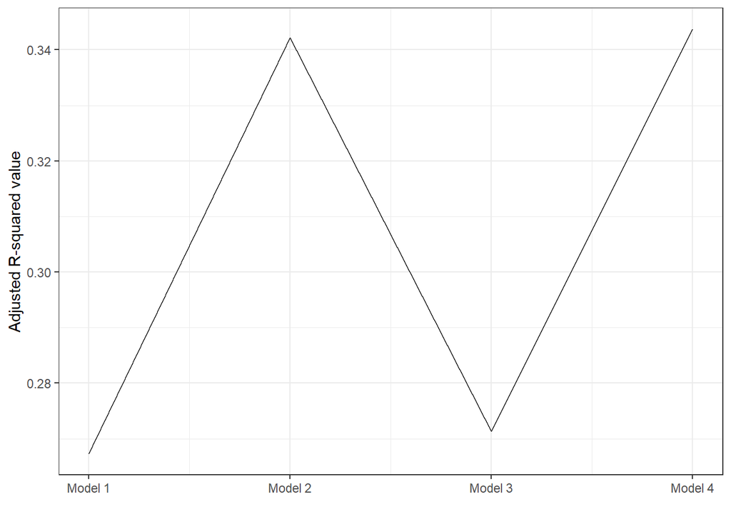

```r
ModelFit <- tibble(model = c(1, 2, 3, 4),
                   R_square = c(summary(model1)$adj.r.squared,
                                summary(model2)$adj.r.squared,
                                summary(model3)$adj.r.squared,
                                summary(model4)$adj.r.squared))

ggplot(ModelFit, aes(x = model, y = R_square)) +
  geom_line() +
  scale_x_continuous(name = "",
                   breaks = breaks <- seq(1, 4, by = 1),
                   labels = paste("Model", breaks)) +
  scale_y_continuous(name = "Adjusted R-squared value") +
  theme_bw()
```

The graph tells me that model4 has the best improvement on overall fit of my regression model.

Below I will compare the coefficient change in each variable between model1 and model4 in a table.

```r
coeff_names <- c(
                 "Public transit percentage" = "pct_publictrans",
                 "Log of median Income" = "log(med_incomeE)",
                 "Median Income" = "med_incomeE",

                 "Asian(compared to White)" = "maj_raceAsian not Hispanic/Latino",
                 "Black(compared to White)" = "maj_raceBlack not Hispanic/Latino",
                 "Hispanic and Latino(compared to White)" = "maj_raceBlack not Hispanic/Latino",
                 "No Racial Majority(compared to White)" = "maj_raceNo Majority",

                 "Majority Foreign Born(compared to Native)" = 'maj_foreignTRUE',

                 "Interaction:\nAsian and Log of Median Income" =
                    "log(med_incomeE):maj_raceAsian not Hispanic/Latino",

                 "Interaction:\nBlack and Log of Median Income" =
                    "log(med_incomeE):maj_raceBlack not Hispanic/Latino",

                 "Interaction:\nHispanic/Latino and Log of Median Income" =
                    "log(med_incomeE):maj_raceHispanic/Latino",

                 "Interaction:\nNo Majority and Log of Median Income" =
                    "log(med_incomeE):maj_raceNo Majority"
                  )




export_summs(model1, model4,
             error_format = "(p = {p.value})",
             error_pos = "same",
             model.names = c("Initial model", "Preferred model"),
             coefs = coeff_names)
```

|  | Initial model | Preferred model |
| --- | --- | --- |
| Public transit percentage | 0.11 *** (p = 0.00) | 0.11 *** (p = 0.00) |
| Log of median Income |  | 6.03 *** (p = 0.00) |
| Median Income | 0.00 *** (p = 0.00) |  |
| Asian(compared to White) | -1.20 (p = 0.54) | -20.76 (p = 0.52) |
| Black(compared to White) | 4.28 *** (p = 0.00) | 13.84 (p = 0.72) |
| Hispanic and Latino(compared to White) |  |  |
| No Racial Majority(compared to White) | 0.82 (p = 0.06) | -11.05 (p = 0.28) |
| Majority Foreign Born(compared to Native) | 2.94 ** (p = 0.00) | 2.32 * (p = 0.02) |
| Interaction: Asian and Log of Median Income |  | 1.99 (p = 0.53) |
| Interaction: Black and Log of Median Income |  | -0.92 (p = 0.81) |
| Interaction: Hispanic/Latino and Log of Median Income |  | 4.53 * (p = 0.02) |
| Interaction: No Majority and Log of Median Income |  | 1.22 (p = 0.22) |
| N | 1459 | 1459 |
| R2 | 0.27 | 0.35 |
| *** p < 0.001; ** p < 0.01; * p < 0.05. |  |  |

[figure not shown]

```r
coeff_desc <- c("Majority Asian AND Doubling in Median Income" =
                  "log(med_incomeE):maj_raceAsian not Hispanic/Latino",

                "Majority Black AND Doubling in Median Income" =
                  "log(med_incomeE):maj_raceBlack not Hispanic/Latino",

                "Majority Hispanic/Latin AND Doubling in Median Income" =
                  "log(med_incomeE):maj_raceHispanic/Latino",

                "No Majority AND Doubling in Median Income" =
                  "log(med_incomeE):maj_raceNo Majority",

                 "1 percentage increase in\n share of public transit" = "pct_publictrans",

                 "Asian\n(compared to White)" = "maj_raceAsian not Hispanic/Latino",
                 "Black\n(compared to White)" = "maj_raceBlack not Hispanic/Latino",
                 "Hispanic and Latino\n(compared to White)" = "maj_raceBlack not Hispanic/Latino",
                 "No Racial Majority\n(compared to White)" = "maj_raceNo Majority",

                 "Majority Native\n(compared to Foreign-born)" = 'maj_foreignTRUE')



plot_coefs(model4,
           coefs = coeff_desc,
           plot.distributions = TRUE,
           rescale.distributions = TRUE) +
  scale_x_continuous(name = "Effect on percentage of workforce using public transit to workplace")
```

```
## Using data tract_data from global environment. This could cause incorrect
## results if tract_data has been altered since the model was fit. You can
## manually provide the data to the "data =" argument.
```

```
## which will replace the existing scale.
```

```
## which will replace the existing scale.
```

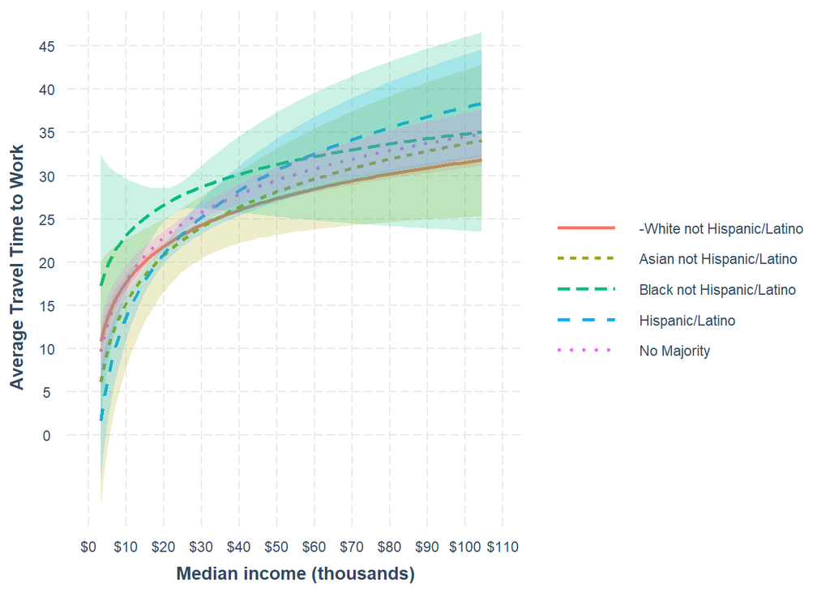

```r
interact_plot(model4, pred = med_incomeE, modx = maj_race, interval = TRUE) +
  scale_x_continuous(name = "Median income (thousands)",
                     limits = c(0, 110000),
                     breaks = breaks <- seq(0, 110000, by = 10000),
                     labels = paste("$",
                                    prettyNum(breaks/1000, big.mark = "'"),
                                    sep = "")) +
  scale_y_continuous(name = "Average Travel Time to Work",
                     breaks = breaks <- seq(0, 50, by = 5)) +
  scale_color_discrete(name = "") +
  scale_linetype_discrete(name = "") +
  scale_fill_discrete(name = "")
```

```
## Using data tract_data from global environment. This could cause incorrect
## results if tract_data has been altered since the model was fit. You can
## manually provide the data to the "data =" argument.
```

```
## which will replace the existing scale.
```

[figure not shown]

```r
cat_plot(model4, pred = maj_race, modx = maj_foreign , interval = TRUE) +
 scale_x_discrete(name = "Majority Race",
                    labels = c("Asian", "Black","HIspanic/Latino",
                               "No Majority","White")) +
  scale_y_continuous(name = "Public Transit Percenatge",
                     breaks = seq(0, 45, by = 5)) +
  scale_color_discrete(name = "") +
  scale_linetype_discrete(name = "") +
  scale_fill_discrete(name = "")
```

Since I do not have an interactive term between majority race and nativity, the differencec between native and foreign-born are consistent among all racial groups.